# NEUROSYSM930

Practical programming session in R - Day 1 parts 1 and 2

Dimitrios Kleftogiannis

4 December 2024

# General info about the course

- Who we are ?

  **Dimi (teacher Day 1 and 2)** https://www4.uib.no/en/find-employees/Dimitrios.Kleftogiannis

  **Gon (teacher Day 3)** https://www4.uib.no/en/find-employees/Gonzalo.Sanchez.Nido

  **Eirik (teaching assistant and admin)** https://www4.uib.no/finn-ansatte/Eirik.Tveit.Solheim
- GitHub page with workshop material https://github.com/dkleftogi/NEUROSYSMED930_R_workshop
- our UiB Mitt page https://mitt.uib.no/courses/47992

# Recap from the lecture slides

First we will focus on basic programming concepts that were already mentioned in the document **RTutorial_beforecourse.pdf** that was pre-requested for you to read.

Load an installed package

```r
# 1.1
library(ggplot2)
```

The `ggplot2` package is a very popular package for data visualisation. We will use it later on in more detail.

For now we are going to inspect some data that are coming together with this package.In this way you will become familiar with the Rstudio interface in case you have not seen it before…

Remember that we can always ask R for help.

```r
help(diamonds)
View(diamonds)
```

### Quick warm up with arithmetics

Lets’ do little arithmetics with R:

- write R code in the console
- every line of code is interpreted and executed by R
- you get a message whether or not your code was correct
- the output of your R code is then shown in the console
- use # sign to add comments next to the commands

```r
# 1.2
10^2 + 36     # ^ is executed before +
```

```
[1] 136
```

```r
3 + 5 * 2 # * is executed first
```

```
[1] 13
```

```r
(3 + 5) * 2 # the parenthesis make things easier to read
```

```
[1] 16
```

```r
3 + 5 * 2 ^ 2  # because this is hard to read
```

```
[1] 23
```

```r
(3 + (5 * (2 ^ 2)))    # clear, if you remember the rules
```

```
[1] 23
```

```r
2/10000     #really small or large numbers get a scientific notation: `2 * 10^(-4)`.
```

```
[1] 2e-04
```

```r
5e3  # note the lack of minus here
```

```
[1] 5000
```

You have already appreciated that the order of operators matter, and that it is a good programming practise to use parentheses and make easy to read commands.

### Mathematical functions

R has many built in mathematical functions. To call a function,we simply type its name, followed by open and closing parentheses.Anything we type inside the parentheses is called the function’s arguments.

```r
#1.3
sum(10, 20, 30, 40, 50)
```

```
[1] 150
```

```r
sin(1)  # trigonometry functions
```

```
[1] 0.841471
```

```r
log(1)  # natural logarithm loge()
```

```
[1] 0
```

```r
log10(10) # base-10 logarithm
```

```
[1] 1
```

Don’t worry about trying to remember every function in R. You can simply Google them. As already mentioned we can always ask R for help. Typing a `?` before the name of a command will open the same help page for that command.

### Comparing things

We can also do comparisons in R. It is relatively easy to remember the operators, but the **==** and **=** need a bit of attention.

```r
# 1.4 comparing things
1 == 1    #equality (note two equals signs, read as "is equal to")
```

```
[1] TRUE
```

```r
1 != 4    #inequality (read as "is not equal to")
```

```
[1] TRUE
```

```r
1 < 2     #less than
```

```
[1] TRUE
```

```r
1 <= 1    #less than or equal to
```

```
[1] TRUE
```

```r
1 > 0     #greater than
```

```
[1] TRUE
```

```r
1 >= -9   #greater than or equal to
```

```
[1] TRUE
```

### Variables

A fundamental concept in programming is a **variable**.

In more general terms, a variable is a piece of memory that stores a value that can be changed. A variable can refer to anything from numbers and strings to objects, collections, and pointers. Variables are essential in software programs, and without them most modern computing functions would be impossible.

In our course and in the next sections

- a variable allows you to store a value (e.g. 4) or an object (e.g. a function description) in R
- use this variable’s name to easily access the value or the object that is stored within this variable.

```r
#1.5
x <- 100
x <- x + 1
y <- x * 2
x <- sum
x(10,100)
```

```
[1] 110
```

## R exercise on variables (e1.5)

Which of the following are valid R variable names?

- min_height
- max.height
- _age
- .mass
- MaxLength
- min-length
- 2widths
- celsius2kelvin

# Data types

R offers numerous **data types**: e.g.

- decimal values like 4.5 are called **numerics**
- natural numbers like 4 are called **integers**
- Boolean values (`TRUE` or `FALSE`) are called **logical**
- `Date` for date and time
- text (or string) values are called **characters**.

```r
#1.6
my_numeric <- 42.5
my_character <- "some text"
my_logical <- TRUE
my_date <- as.Date("05/29/2018", "%m/%d/%Y")
my_numeric_str <- '42.5'

#un-comment the follow and try to run
#my_numeric_str + 1

my_numeric + 1
```

```
[1] 43.5
```

We can verify the data type of a variable with the `class()` function:

```r
class(my_numeric)
```

```
[1] "numeric"
```

```r
class(my_date)
```

```
[1] "Date"
```

```r
class(my_numeric_str)
```

```
[1] "character"
```

### List objects in the environment and delete objects

```r
ls()
```

```
[1] "my_character"   "my_date"        "my_logical"     "my_numeric"
[5] "my_numeric_str" "x"              "y"
```

```r
ls(pat='max.') #list objects with a pattern in the file name
```

```
character(0)
```

```r
ls(pat='my_')
```

```
[1] "my_character"   "my_date"        "my_logical"     "my_numeric"
[5] "my_numeric_str"
```

```r
ls(all.names = TRUE)
```

```
[1] "my_character"   "my_date"        "my_logical"     "my_numeric"
[5] "my_numeric_str" "x"              "y"
```

```r
#remove objects from the environment
rm(my_numeric)                            # remove a single object
rm(my_character, my_logical)              # remove multiple objects
rm(list = c('my_date', 'my_numeric_str'))     # remove a list of objects
rm(list = ls())
```

### Vectors

A **vector** is a simple structure to store data:

- one-dimension arrays that can hold numeric data, character data, or logical data
- you create a vector with the combine function `c()`
- operations can be applied to each element of the vector automatically

Here are some examples:

```r
# 1.6.1 Vectors
my_vector <- c(1, 2, 3, 4)
my_vector > 4
```

```
[1] FALSE FALSE FALSE FALSE
```

```r
x <- 1:5
my_vector_2 <- c(0, x, 20, 0)
my_vector_2[2]       # inspect entry 2 from vector my_vector_2
```

```
[1] 1
```

```r
my_vector_2[2:3]     # inspect entries 2 and 3
```

```
[1] 1 2
```

```r
my_vector_2[c(1:3)]
```

```
[1] 0 1 2
```

```r
length(my_vector_2)  # get vector length
```

```
[1] 8
```

```r
my_games <- c("basketball", "ski", "billiard")
my_games
```

```
[1] "basketball" "ski"        "billiard"
```

We need to know about something called *type coercion*, in R. It is often the source of many surprises and the reason why we need to be aware of the basic data types and how R will interpret them. When R encounters a mix of types (here numeric and character) to be combined into a single vector, it will force them all to be the same type.

Lets see some examples:

```r
coercion_vector <- c('a', TRUE)
coercion_vector
```

```
[1] "a"    "TRUE"
```

```r
another_coercion_vector <- c(0, TRUE)
another_coercion_vector
```

```
[1] 0 1
```

```r
character_vector_example <- c('1','2','4')
character_vector_example
```

```
[1] "1" "2" "4"
```

```r
#character_vector_example + 1
character_coerced_to_numeric <- as.numeric(character_vector_example)
character_coerced_to_numeric
```

```
[1] 1 2 4
```

```r
character_coerced_to_numeric <- character_coerced_to_numeric - 1
character_coerced_to_numeric
```

```
[1] 0 1 3
```

```r
numeric_coerced_to_logical <- as.logical(character_coerced_to_numeric)
numeric_coerced_to_logical
```

```
[1] FALSE  TRUE  TRUE
```

The coercion rules go: `logical` -> `integer` -> `double`/`numeric` -> `complex` -> `character`,

where -> can be read as *are transformed into

**In conclusion**

Some surprising things can happen when R forces one basic data type into another….

Be careful and always inspect your data from one part of the analysis to another

### Matrices

A **matrix** is:

- a collection of elements of the same data type (numeric, character, or logical)
- fixed number of rows and columns.

Here are some examples:

```r
# 1.6.2 matrices

my_matrix <- matrix(1:12, nrow=3,ncol=4, byrow = TRUE)
my_matrix
```

```
     [,1] [,2] [,3] [,4]
[1,]    1    2    3    4
[2,]    5    6    7    8
[3,]    9   10   11   12
```

```r
my_matrix[2, 4]
```

```
[1] 8
```

```r
class(my_matrix)
```

```
[1] "matrix" "array"
```

```r
typeof(my_matrix)
```

```
[1] "integer"
```

```r
my_matrix[2, 4] <- 4.33
typeof(my_matrix)
```

```
[1] "double"
```

```r
str(my_matrix)
```

```
 num [1:3, 1:4] 1 5 9 2 6 10 3 7 11 4 ...
```

```r
dim(my_matrix)
```

```
[1] 3 4
```

```r
ncol(my_matrix)
```

```
[1] 4
```

```r
nrow(my_matrix)
```

```
[1] 3
```

**Note on Missing Values**

In real data analysis, it is often the case that we are missing some data in a data set. For example, say we study cats and we want to add tail length to our dataset, but one of our cats wouldn’t hold still long enough to be measured… we know it has a tail (so we can’t record it as `0`), but we don’t know what it is. We also can’t record it using a word or code (character; such as `"missing"`) because vectors in R all have to be the same type, and weight is numeric. A common practice is to use a placeholder value such as `9999`, but that can cause problems if we neglect to deal with it properly, so it’s not recommended.

R has a special placeholder for missing values called `NA` - it looks a lot like a character value, but it is not - it is a special value that has the same type as the vector in which it is found.

```r
my_matrix[2,3] <- NA
my_matrix
```

```
     [,1] [,2] [,3]  [,4]
[1,]    1    2    3  4.00
[2,]    5    6   NA  4.33
[3,]    9   10   11 12.00
```

### Data frames and tibbles

A **data frame**:

- is pretty much the *de facto* data structure for most tabular data
- variables of a data set as columns and the observations as rows.

–

A **tibble**:

- a.k.a `tbl`
- a type of data frame common in the `tidyverse`
- slightly different default behaviour than data frames. Check the following website for more info https://cran.r-project.org/web/packages/tibble/vignettes/tibble.html

Let’s see some examples here:

```r
# 1.6.3
library(ggplot2) #i had to load it again otherwise diamonds dataset was missing...

#help(mtcars)
mtcars
```

```
                     mpg cyl  disp  hp drat    wt  qsec vs am gear carb
Mazda RX4           21.0   6 160.0 110 3.90 2.620 16.46  0  1    4    4
Mazda RX4 Wag       21.0   6 160.0 110 3.90 2.875 17.02  0  1    4    4
Datsun 710          22.8   4 108.0  93 3.85 2.320 18.61  1  1    4    1
Hornet 4 Drive      21.4   6 258.0 110 3.08 3.215 19.44  1  0    3    1
Hornet Sportabout   18.7   8 360.0 175 3.15 3.440 17.02  0  0    3    2
Valiant             18.1   6 225.0 105 2.76 3.460 20.22  1  0    3    1
Duster 360          14.3   8 360.0 245 3.21 3.570 15.84  0  0    3    4
Merc 240D           24.4   4 146.7  62 3.69 3.190 20.00  1  0    4    2
Merc 230            22.8   4 140.8  95 3.92 3.150 22.90  1  0    4    2
Merc 280            19.2   6 167.6 123 3.92 3.440 18.30  1  0    4    4
Merc 280C           17.8   6 167.6 123 3.92 3.440 18.90  1  0    4    4
Merc 450SE          16.4   8 275.8 180 3.07 4.070 17.40  0  0    3    3
Merc 450SL          17.3   8 275.8 180 3.07 3.730 17.60  0  0    3    3
Merc 450SLC         15.2   8 275.8 180 3.07 3.780 18.00  0  0    3    3
Cadillac Fleetwood  10.4   8 472.0 205 2.93 5.250 17.98  0  0    3    4
Lincoln Continental 10.4   8 460.0 215 3.00 5.424 17.82  0  0    3    4
Chrysler Imperial   14.7   8 440.0 230 3.23 5.345 17.42  0  0    3    4
Fiat 128            32.4   4  78.7  66 4.08 2.200 19.47  1  1    4    1
Honda Civic         30.4   4  75.7  52 4.93 1.615 18.52  1  1    4    2
Toyota Corolla      33.9   4  71.1  65 4.22 1.835 19.90  1  1    4    1
Toyota Corona       21.5   4 120.1  97 3.70 2.465 20.01  1  0    3    1
Dodge Challenger    15.5   8 318.0 150 2.76 3.520 16.87  0  0    3    2
AMC Javelin         15.2   8 304.0 150 3.15 3.435 17.30  0  0    3    2
Camaro Z28          13.3   8 350.0 245 3.73 3.840 15.41  0  0    3    4
Pontiac Firebird    19.2   8 400.0 175 3.08 3.845 17.05  0  0    3    2
Fiat X1-9           27.3   4  79.0  66 4.08 1.935 18.90  1  1    4    1
Porsche 914-2       26.0   4 120.3  91 4.43 2.140 16.70  0  1    5    2
Lotus Europa        30.4   4  95.1 113 3.77 1.513 16.90  1  1    5    2
Ford Pantera L      15.8   8 351.0 264 4.22 3.170 14.50  0  1    5    4
Ferrari Dino        19.7   6 145.0 175 3.62 2.770 15.50  0  1    5    6
Maserati Bora       15.0   8 301.0 335 3.54 3.570 14.60  0  1    5    8
Volvo 142E          21.4   4 121.0 109 4.11 2.780 18.60  1  1    4    2
```

```r
head(mtcars)
```

```
                   mpg cyl disp  hp drat    wt  qsec vs am gear carb
Mazda RX4         21.0   6  160 110 3.90 2.620 16.46  0  1    4    4
Mazda RX4 Wag     21.0   6  160 110 3.90 2.875 17.02  0  1    4    4
Datsun 710        22.8   4  108  93 3.85 2.320 18.61  1  1    4    1
Hornet 4 Drive    21.4   6  258 110 3.08 3.215 19.44  1  0    3    1
Hornet Sportabout 18.7   8  360 175 3.15 3.440 17.02  0  0    3    2
Valiant           18.1   6  225 105 2.76 3.460 20.22  1  0    3    1
```

```r
str(mtcars)
```

```
'data.frame':   32 obs. of  11 variables:
 $ mpg : num  21 21 22.8 21.4 18.7 18.1 14.3 24.4 22.8 19.2 ...
 $ cyl : num  6 6 4 6 8 6 8 4 4 6 ...
 $ disp: num  160 160 108 258 360 ...
 $ hp  : num  110 110 93 110 175 105 245 62 95 123 ...
 $ drat: num  3.9 3.9 3.85 3.08 3.15 2.76 3.21 3.69 3.92 3.92 ...
 $ wt  : num  2.62 2.88 2.32 3.21 3.44 ...
 $ qsec: num  16.5 17 18.6 19.4 17 ...
 $ vs  : num  0 0 1 1 0 1 0 1 1 1 ...
 $ am  : num  1 1 1 0 0 0 0 0 0 0 ...
 $ gear: num  4 4 4 3 3 3 3 4 4 4 ...
 $ carb: num  4 4 1 1 2 1 4 2 2 4 ...
```

```r
dim(mtcars)
```

```
[1] 32 11
```

```r
colnames(mtcars)
```

```
 [1] "mpg"  "cyl"  "disp" "hp"   "drat" "wt"   "qsec" "vs"   "am"   "gear"
[11] "carb"
```

```r
rownames(mtcars)
```

```
 [1] "Mazda RX4"           "Mazda RX4 Wag"       "Datsun 710"
 [4] "Hornet 4 Drive"      "Hornet Sportabout"   "Valiant"
 [7] "Duster 360"          "Merc 240D"           "Merc 230"
[10] "Merc 280"            "Merc 280C"           "Merc 450SE"
[13] "Merc 450SL"          "Merc 450SLC"         "Cadillac Fleetwood"
[16] "Lincoln Continental" "Chrysler Imperial"   "Fiat 128"
[19] "Honda Civic"         "Toyota Corolla"      "Toyota Corona"
[22] "Dodge Challenger"    "AMC Javelin"         "Camaro Z28"
[25] "Pontiac Firebird"    "Fiat X1-9"           "Porsche 914-2"
[28] "Lotus Europa"        "Ford Pantera L"      "Ferrari Dino"
[31] "Maserati Bora"       "Volvo 142E"
```

```r
#View(mtcars)

#the operator $
mtcars$cyl
```

```
 [1] 6 6 4 6 8 6 8 4 4 6 6 8 8 8 8 8 8 4 4 4 4 8 8 8 8 4 4 4 8 6 8 4
```

```r
mtcars[,2]
```

```
 [1] 6 6 4 6 8 6 8 4 4 6 6 8 8 8 8 8 8 4 4 4 4 8 8 8 8 4 4 4 8 6 8 4
```

```r
mtcars[,'cyl']
```

```
 [1] 6 6 4 6 8 6 8 4 4 6 6 8 8 8 8 8 8 4 4 4 4 8 8 8 8 4 4 4 8 6 8 4
```

```r
typeof(mtcars$cyl)
```

```
[1] "double"
```

```r
summary(mtcars$cyl)   # use $ to extract another variable from a data frame
```

```
   Min. 1st Qu.  Median    Mean 3rd Qu.    Max.
  4.000   4.000   6.000   6.188   8.000   8.000
```

```r
mtcars$mpg
```

```
 [1] 21.0 21.0 22.8 21.4 18.7 18.1 14.3 24.4 22.8 19.2 17.8 16.4 17.3 15.2 10.4
[16] 10.4 14.7 32.4 30.4 33.9 21.5 15.5 15.2 13.3 19.2 27.3 26.0 30.4 15.8 19.7
[31] 15.0 21.4
```

```r
summary(mtcars$mpg)
```

```
   Min. 1st Qu.  Median    Mean 3rd Qu.    Max.
  10.40   15.43   19.20   20.09   22.80   33.90
```

```r
#Inspect a built-in tibble
#help(diamonds)
str(diamonds)  # built-in in library ggplot2
```

```
tibble [53,940 × 10] (S3: tbl_df/tbl/data.frame)
 $ carat  : num [1:53940] 0.23 0.21 0.23 0.29 0.31 0.24 0.24 0.26 0.22 0.23 ...
 $ cut    : Ord.factor w/ 5 levels "Fair"<"Good"<..: 5 4 2 4 2 3 3 3 1 3 ...
 $ color  : Ord.factor w/ 7 levels "D"<"E"<"F"<"G"<..: 2 2 2 6 7 7 6 5 2 5 ...
 $ clarity: Ord.factor w/ 8 levels "I1"<"SI2"<"SI1"<..: 2 3 5 4 2 6 7 3 4 5 ...
 $ depth  : num [1:53940] 61.5 59.8 56.9 62.4 63.3 62.8 62.3 61.9 65.1 59.4 ...
 $ table  : num [1:53940] 55 61 65 58 58 57 57 55 61 61 ...
 $ price  : int [1:53940] 326 326 327 334 335 336 336 337 337 338 ...
 $ x      : num [1:53940] 3.95 3.89 4.05 4.2 4.34 3.94 3.95 4.07 3.87 4 ...
 $ y      : num [1:53940] 3.98 3.84 4.07 4.23 4.35 3.96 3.98 4.11 3.78 4.05 ...
 $ z      : num [1:53940] 2.43 2.31 2.31 2.63 2.75 2.48 2.47 2.53 2.49 2.39 ...
```

```r
head(diamonds)
```

```
# A tibble: 6 × 10
  carat cut       color clarity depth table price     x     y     z
  <dbl> <ord>     <ord> <ord>   <dbl> <dbl> <int> <dbl> <dbl> <dbl>
1  0.23 Ideal     E     SI2      61.5    55   326  3.95  3.98  2.43
2  0.21 Premium   E     SI1      59.8    61   326  3.89  3.84  2.31
3  0.23 Good      E     VS1      56.9    65   327  4.05  4.07  2.31
4  0.29 Premium   I     VS2      62.4    58   334  4.2   4.23  2.63
5  0.31 Good      J     SI2      63.3    58   335  4.34  4.35  2.75
6  0.24 Very Good J     VVS2     62.8    57   336  3.94  3.96  2.48
```

```r
dim(diamonds)
```

```
[1] 53940    10
```

```r
colnames(diamonds)
```

```
 [1] "carat"   "cut"     "color"   "clarity" "depth"   "table"   "price"
 [8] "x"       "y"       "z"
```

```r
#rownames(diamonds)
#View(diamonds)
```

### Lists

A **list** allows you to

- gather a variety of objects under one name in an ordered way
- these objects can be matrices, vectors, data frames, even other lists
- a list is some kind super data type
- you can store practically any piece of information in it!
- but nested lists can be easily out of control…

```r
# 1.6.4

my_list <- list(A = 1,
                B = c(1:20),
                C = seq(1, 4, length=5),
                D = c("Dimi", "Gon",'Eirik','Nina'))

names(my_list)
```

```
[1] "A" "B" "C" "D"
```

```r
str(my_list)
```

```
List of 4
 $ A: num 1
 $ B: int [1:20] 1 2 3 4 5 6 7 8 9 10 ...
 $ C: num [1:5] 1 1.75 2.5 3.25 4
 $ D: chr [1:4] "Dimi" "Gon" "Eirik" "Nina"
```

```r
#explore different ways to access the lists
my_list$A
```

```
[1] 1
```

```r
my_list$D
```

```
[1] "Dimi"  "Gon"   "Eirik" "Nina"
```

```r
my_list[[2]]
```

```
 [1]  1  2  3  4  5  6  7  8  9 10 11 12 13 14 15 16 17 18 19 20
```

```r
my_list[3]
```

```
$C
[1] 1.00 1.75 2.50 3.25 4.00
```

```r
my_list[[3]]
```

```
[1] 1.00 1.75 2.50 3.25 4.00
```

```r
#what about this ?
my_list$E <- mtcars
str(my_list)
```

```
List of 5
 $ A: num 1
 $ B: int [1:20] 1 2 3 4 5 6 7 8 9 10 ...
 $ C: num [1:5] 1 1.75 2.5 3.25 4
 $ D: chr [1:4] "Dimi" "Gon" "Eirik" "Nina"
 $ E:'data.frame':  32 obs. of  11 variables:
  ..$ mpg : num [1:32] 21 21 22.8 21.4 18.7 18.1 14.3 24.4 22.8 19.2 ...
  ..$ cyl : num [1:32] 6 6 4 6 8 6 8 4 4 6 ...
  ..$ disp: num [1:32] 160 160 108 258 360 ...
  ..$ hp  : num [1:32] 110 110 93 110 175 105 245 62 95 123 ...
  ..$ drat: num [1:32] 3.9 3.9 3.85 3.08 3.15 2.76 3.21 3.69 3.92 3.92 ...
  ..$ wt  : num [1:32] 2.62 2.88 2.32 3.21 3.44 ...
  ..$ qsec: num [1:32] 16.5 17 18.6 19.4 17 ...
  ..$ vs  : num [1:32] 0 0 1 1 0 1 0 1 1 1 ...
  ..$ am  : num [1:32] 1 1 1 0 0 0 0 0 0 0 ...
  ..$ gear: num [1:32] 4 4 4 3 3 3 3 4 4 4 ...
  ..$ carb: num [1:32] 4 4 1 1 2 1 4 2 2 4 ...
```

### Factors

Another important data structure is called a *factor*. Factors usually look like character data, but are typically used to represent categorical information that have a defined set of values.In modeling functions, it’s important to know what the baseline levels are. This is assumed to be the first factor, but by default factors are labeled in alphabetical order.

```r
# 1.6.5
mydata <- c("patient","patient","patient" ,"control", "control", "patient")
mydata
```

```
[1] "patient" "patient" "patient" "control" "control" "patient"
```

```r
factor_ordering_example <- factor(mydata, levels = c("patient", "control"))
factor_ordering_example
```

```
[1] patient patient patient control control patient
Levels: patient control
```

```r
str(factor_ordering_example)
```

```
 Factor w/ 2 levels "patient","control": 1 1 1 2 2 1
```

For now we will not provide more information, but in the following parts and exercises we will showcase more examples.

## R exercise on data types (e1.6)

1. Create a vector `fav_music` with the names of your favourite artists/bands.
2. Create a vector `num_records` with the number of records you have in your collection of each of those artists.
3. Create a vector `num_concerts` with the number of times you attended a concert of these artists.
4. Put everything together in a data frame, assign the name `my_music` to this data frame and change the labels of the information stored in the columns to `artist`, `records` and `concerts`.
5. Extract the variable `num_records` from the data frame `my_music`.
6. Calculate the total number of records in your collection (for the defined set of artists).
7. Check the structure of the data frame, ask for a `summary`.

# Data importation and exportation

Very often in real life analyses we have to read data from an external file for example a txt file from the lab or an excel file with clinical information of patients.

Thus it is very important to be able to read the data in R. It is equally important to be able to write our results in files that are stored in the hard drive. We might have to send some results to colleagues that cannot use R, or even for our publications might be required to provide supplementary files in tabular format.

But to begin with, it is very important to orient our self, and point our working space in Rstudio to the correct location in the hard drive. You need to remember of course the structure of your file system…

```r
getwd()
```

```
[1] "/Users/kleftogi/Library/CloudStorage/Dropbox/My Mac (c02z46udlvdc.klientdrift.uib.no)/Desktop/Journal_clubs_and_Students/NEUROSYSMED930_R_workshop/Days_1_2"
```

```r
setwd('/Users/kleftogi/Desktop/Journal_clubs_and_Students/R_programming_prep/My_R_repo/')

#use a full path
path <- file.path("/Users/kleftogi/Desktop/Journal_clubs_and_Students/R_programming_prep/My_R_repo/")
#use a relative path
path <- file.path('./Days_1_2/')
```

### Import a txt file

```r
# 1.7
path <- file.path("/Users/kleftogi/Desktop/Journal_clubs_and_Students/R_programming_prep/My_R_repo/data")
path.hotdogs <- file.path(path, "hotdogs.txt")
path.hotdogs
```

```
[1] "/Users/kleftogi/Desktop/Journal_clubs_and_Students/R_programming_prep/My_R_repo/data/hotdogs.txt"
```

```r
hotdogs <- read.table(path.hotdogs, header = FALSE,
                      col.names = c("type", "calories", "sodium"))

str(hotdogs)    # inspect data imported
```

```
'data.frame':   54 obs. of  3 variables:
 $ type    : chr  "Beef" "Beef" "Beef" "Beef" ...
 $ calories: int  186 181 176 149 184 190 158 139 175 148 ...
 $ sodium  : int  495 477 425 322 482 587 370 322 479 375 ...
```

```r
dim(hotdogs)
```

```
[1] 54  3
```

```r
#View(hotdogs)
head(hotdogs)
```

```
  type calories sodium
1 Beef      186    495
2 Beef      181    477
3 Beef      176    425
4 Beef      149    322
5 Beef      184    482
6 Beef      190    587
```

```r
#find the unique values in the type column
unique(hotdogs$type)
```

```
[1] "Beef"    "Meat"    "Poultry"
```

### Import a csv file

```r
# 1.8
path.pools <- file.path(path, "swimming_pools.csv")
path.pools
```

```
[1] "/Users/kleftogi/Desktop/Journal_clubs_and_Students/R_programming_prep/My_R_repo/data/swimming_pools.csv"
```

```r
pools <- read.csv(path.pools)
str(pools)    # inspect data imported
```

```
'data.frame':   20 obs. of  4 variables:
 $ Name     : chr  "Acacia Ridge Leisure Centre" "Bellbowrie Pool" "Carole Park" "Centenary Pool (inner City)" ...
 $ Address  : chr  "1391 Beaudesert Road, Acacia Ridge" "Sugarwood Street, Bellbowrie" "Cnr Boundary Road and Waterford Road Wacol" "400 Gregory Terrace, Spring Hill" ...
 $ Latitude : num  -27.6 -27.6 -27.6 -27.5 -27.4 ...
 $ Longitude: num  153 153 153 153 153 ...
```

```r
dim(pools)
```

```
[1] 20  4
```

```r
#View(pools)
head(pools)
```

```
                         Name                                    Address
1 Acacia Ridge Leisure Centre         1391 Beaudesert Road, Acacia Ridge
2             Bellbowrie Pool               Sugarwood Street, Bellbowrie
3                 Carole Park Cnr Boundary Road and Waterford Road Wacol
4 Centenary Pool (inner City)           400 Gregory Terrace, Spring Hill
5              Chermside Pool               375 Hamilton Road, Chermside
6 Colmslie Pool (Morningside)               400 Lytton Road, Morningside
   Latitude Longitude
1 -27.58616  153.0264
2 -27.56547  152.8911
3 -27.60744  152.9315
4 -27.45537  153.0251
5 -27.38583  153.0351
6 -27.45516  153.0789
```

```r
unique(pools$Address)
```

```
 [1] "1391 Beaudesert Road, Acacia Ridge"
 [2] "Sugarwood Street, Bellbowrie"
 [3] "Cnr Boundary Road and Waterford Road Wacol"
 [4] "400 Gregory Terrace, Spring Hill"
 [5] "375 Hamilton Road, Chermside"
 [6] "400 Lytton Road, Morningside"
 [7] "14 Torrington Street, Springhill"
 [8] "794 Oxley Road, Corinda"
 [9] "432 Wickham Street, Fortitude Valley"
[10] "90 Klumpp Road, Upper Mount Gravatt"
[11] "131 Caxton Street, Paddington"
[12] "11 Yallambee Road, Jindalee"
[13] "1 Fairlead Crescent, Manly"
[14] "Cnr wecker Road and Newnham Road, Mansfield"
[15] "100 Edmonstone Street, South Brisbane"
[16] "71 Alderson Stret, Newmarket"
[17] "37 Bonemill Road, Runcorn"
[18] "231 Flinders Parade, Sandgate"
[19] "5 Panitya Street, Stones Corner"
[20] "81 School Road, Yeronga"
```

```r
#lets try now this version of the data importation function
pools <- read.csv(path.pools, stringsAsFactors = TRUE)
str(pools)
```

```
'data.frame':   20 obs. of  4 variables:
 $ Name     : Factor w/ 20 levels "Acacia Ridge Leisure Centre",..: 1 2 3 4 5 6 19 7 8 9 ...
 $ Address  : Factor w/ 20 levels "1 Fairlead Crescent, Manly",..: 5 20 18 10 9 11 6 15 12 17 ...
 $ Latitude : num  -27.6 -27.6 -27.6 -27.5 -27.4 ...
 $ Longitude: num  153 153 153 153 153 ...
```

### Import an excel file

```r
# 1.9
library(readxl)
path.urbanpop <- file.path(path, "urbanpop.xlsx")
path.urbanpop
```

```
[1] "/Users/kleftogi/Desktop/Journal_clubs_and_Students/R_programming_prep/My_R_repo/data/urbanpop.xlsx"
```

```r
excel_sheets(path.urbanpop) # list sheet names with `excel_sheets()`
```

```
[1] "1960-1966" "1967-1974" "1975-2011"
```

```r
#if the sheet argument is not specified, by default the first sheet will be loaded

pop_1 <- read_excel(path.urbanpop, sheet = 1)
pop_2 <- read_excel(path.urbanpop, sheet = 2)
pop_3 <- read_excel(path.urbanpop, sheet = 3)

str(pop_1)
```

```
tibble [209 × 8] (S3: tbl_df/tbl/data.frame)
 $ country: chr [1:209] "Afghanistan" "Albania" "Algeria" "American Samoa" ...
 $ 1960   : num [1:209] 769308 494443 3293999 NA NA ...
 $ 1961   : num [1:209] 814923 511803 3515148 13660 8724 ...
 $ 1962   : num [1:209] 858522 529439 3739963 14166 9700 ...
 $ 1963   : num [1:209] 903914 547377 3973289 14759 10748 ...
 $ 1964   : num [1:209] 951226 565572 4220987 15396 11866 ...
 $ 1965   : num [1:209] 1000582 583983 4488176 16045 13053 ...
 $ 1966   : num [1:209] 1058743 602512 4649105 16693 14217 ...
```

```r
str(pop_2)
```

```
tibble [209 × 9] (S3: tbl_df/tbl/data.frame)
 $ country: chr [1:209] "Afghanistan" "Albania" "Algeria" "American Samoa" ...
 $ 1967   : num [1:209] 1119067 621180 4826104 17349 15440 ...
 $ 1968   : num [1:209] 1182159 639964 5017299 17996 16727 ...
 $ 1969   : num [1:209] 1248901 658853 5219332 18619 18088 ...
 $ 1970   : num [1:209] 1319849 677839 5429743 19206 19529 ...
 $ 1971   : num [1:209] 1409001 698932 5619042 19752 20929 ...
 $ 1972   : num [1:209] 1502402 720207 5815734 20263 22406 ...
 $ 1973   : num [1:209] 1598835 741681 6020647 20742 23937 ...
 $ 1974   : num [1:209] 1696445 763385 6235114 21194 25482 ...
```

```r
str(pop_3)
```

```
tibble [209 × 38] (S3: tbl_df/tbl/data.frame)
 $ country: chr [1:209] "Afghanistan" "Albania" "Algeria" "American Samoa" ...
 $ 1975   : num [1:209] 1793266 785350 6460138 21632 27019 ...
 $ 1976   : num [1:209] 1905033 807990 6774099 22047 28366 ...
 $ 1977   : num [1:209] 2021308 830959 7102902 22452 29677 ...
 $ 1978   : num [1:209] 2142248 854262 7447728 22899 31037 ...
 $ 1979   : num [1:209] 2268015 877898 7810073 23457 32572 ...
 $ 1980   : num [1:209] 2398775 901884 8190772 24177 34366 ...
 $ 1981   : num [1:209] 2493265 927224 8637724 25173 36356 ...
 $ 1982   : num [1:209] 2590846 952447 9105820 26342 38618 ...
 $ 1983   : num [1:209] 2691612 978476 9591900 27655 40983 ...
 $ 1984   : num [1:209] 2795656 1006613 10091289 29062 43207 ...
 $ 1985   : num [1:209] 2903078 1037541 10600112 30524 45119 ...
 $ 1986   : num [1:209] 3006983 1072365 11101757 32014 46254 ...
 $ 1987   : num [1:209] 3113957 1109954 11609104 33548 47019 ...
```

[output cut: 24 more lines]

```r
pop_list <- list(pop_1, pop_2)
names(pop_list)
```

[output not shown]

```r
names(pop_list) <- c('1960-1966',"1967-1974")
names(pop_list)
```

```
[1] "1960-1966" "1967-1974"
```

**Note on data importation**

There are many more packages that allow us to import different data types for example we can import SPSS or Strata files, or even platform-specific data types.For example there are packages to load images, cytometry files called .fcs files, gene expression data or variant calling data.

### Export an excel file

```r
#1.10
library(xlsx)
#change the path to yours
write.xlsx(pop_1, '/Users/kleftogi/Desktop/Journal_clubs_and_Students/R_programming_prep/My_R_repo/data/my_first_export.xlsx', sheetName = "page1",
           col.names = TRUE, row.names = TRUE, append = FALSE)
```

# Our first exploratory data analysis

Now based on what we learned so far we will perform together a data exploration task. We will see different data types and basic functions and we will elaborate a bit more on how we can program other similar analyses in the future.

```r
# 1.11
path.data <- file.path(path, "CPS1985.txt")
CPS1985 <- read.table(path.data, header = TRUE)

head(CPS1985)
```

```
      wage education experience age ethnicity region gender occupation
1     5.10         8         21  35  hispanic  other female     worker
1100  4.95         9         42  57      cauc  other female     worker
2     6.67        12          1  19      cauc  other   male     worker
3     4.00        12          4  22      cauc  other   male     worker
4     7.50        12         17  35      cauc  other   male     worker
5    13.07        13          9  28      cauc  other   male     worker
            sector union married
1    manufacturing    no     yes
1100 manufacturing    no     yes
2    manufacturing    no      no
3            other    no      no
4            other    no     yes
5            other   yes      no
```

```r
colnames(CPS1985)
```

```
 [1] "wage"       "education"  "experience" "age"        "ethnicity"
 [6] "region"     "gender"     "occupation" "sector"     "union"
[11] "married"
```

```r
dim(CPS1985)
```

```
[1] 534  11
```

```r
#first explore a numerical variable
str(CPS1985)
```

```
'data.frame':   534 obs. of  11 variables:
 $ wage      : num  5.1 4.95 6.67 4 7.5 ...
 $ education : int  8 9 12 12 12 13 10 12 16 12 ...
 $ experience: int  21 42 1 4 17 9 27 9 11 9 ...
 $ age       : int  35 57 19 22 35 28 43 27 33 27 ...
 $ ethnicity : chr  "hispanic" "cauc" "cauc" "cauc" ...
 $ region    : chr  "other" "other" "other" "other" ...
 $ gender    : chr  "female" "female" "male" "male" ...
 $ occupation: chr  "worker" "worker" "worker" "worker" ...
 $ sector    : chr  "manufacturing" "manufacturing" "manufacturing" "other" ...
 $ union     : chr  "no" "no" "no" "no" ...
 $ married   : chr  "yes" "yes" "no" "no" ...
```

```r
is.numeric(CPS1985$wage)      # check if variable is numeric
```

```
[1] TRUE
```

```r
summary(CPS1985$wage)         # get a summary
```

```
   Min. 1st Qu.  Median    Mean 3rd Qu.    Max.
  1.000   5.250   7.780   9.024  11.250  44.500
```

```r
quantile(CPS1985$wage)        #similarly get the distribution quantiles
```

```
   0%   25%   50%   75%  100%
 1.00  5.25  7.78 11.25 44.50
```

```r
mean(CPS1985$wage)            # get mean
```

```
[1] 9.024064
```

```r
mean(CPS1985$wage,na.rm = T)            # get mean and skip NA
```

```
[1] 9.024064
```

```r
median(CPS1985$wage)
```

```
[1] 7.78
```

```r
var(CPS1985$wage)             # get variance
```

```
[1] 26.41032
```

```r
sd(CPS1985$wage) #standard deviation
```

```
[1] 5.139097
```

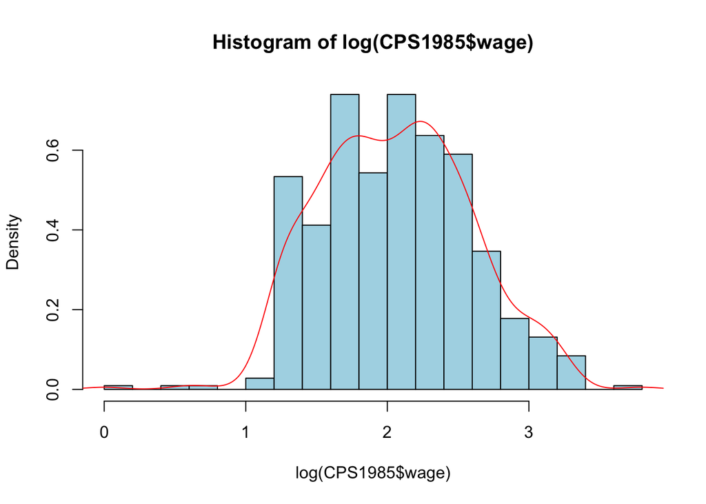

```r
se <- sd(CPS1985$wage)/length(CPS1985$wage) #standard error
#visualize the `wage` distribution with simple R functions
hist(log(CPS1985$wage), freq = FALSE, nclass = 20, col = "light blue")
lines(density(log(CPS1985$wage)), col = "red")
```

```r
#now explore a character variable - example of factor
summary(CPS1985$occupation)
```

```
   Length     Class      Mode
      534 character character
```

```r
table(CPS1985$occupation)
```

```
management     office      sales   services  technical     worker
        55         97         38         83        105        156
```

```r
CPS1985$occupation <- factor(CPS1985$occupation,
                             levels = c("management","office","sales","services","technical","worker" ))

levels(CPS1985$occupation)
```

```
[1] "management" "office"     "sales"      "services"   "technical"
[6] "worker"
```

```r
levels(CPS1985$occupation)[c(1,5)] <- c("mgmt","techn")
summary(CPS1985$occupation)
```

```
    mgmt   office    sales services    techn   worker
      55       97       38       83      105      156
```

```r
table(CPS1985$occupation)
```

```
    mgmt   office    sales services    techn   worker
      55       97       38       83      105      156
```

```r
#visualise the distribution
tab <- table(CPS1985$occupation)
#tab <- tab/nrow(CPS1985)
prop.table(tab)    #Express Table Entries as Fraction of Marginal Table
```

```
      mgmt     office      sales   services      techn     worker
0.10299625 0.18164794 0.07116105 0.15543071 0.19662921 0.29213483
```

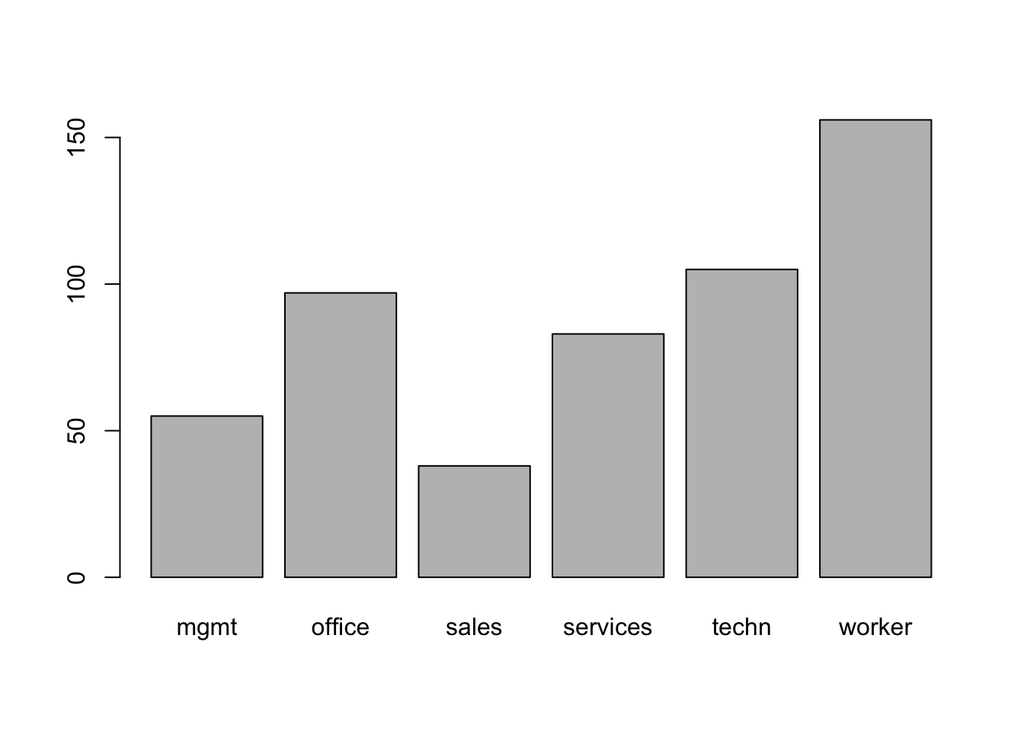

```r
barplot(tab)
```

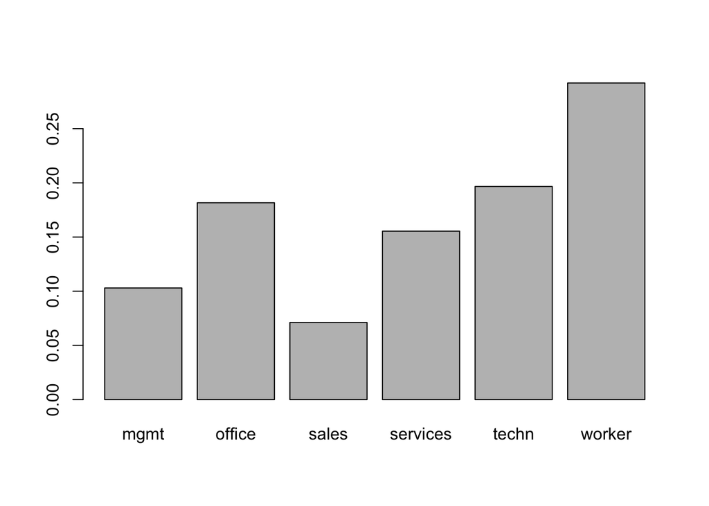

```r
barplot(prop.table(tab))
```

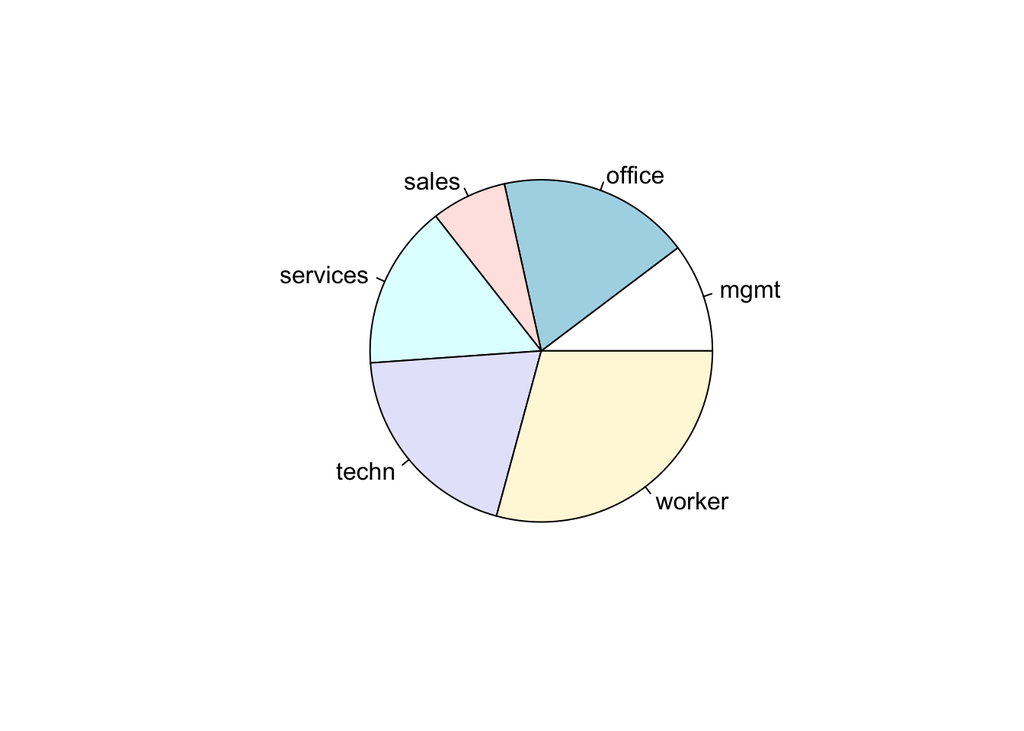

```r
pie(tab)
```

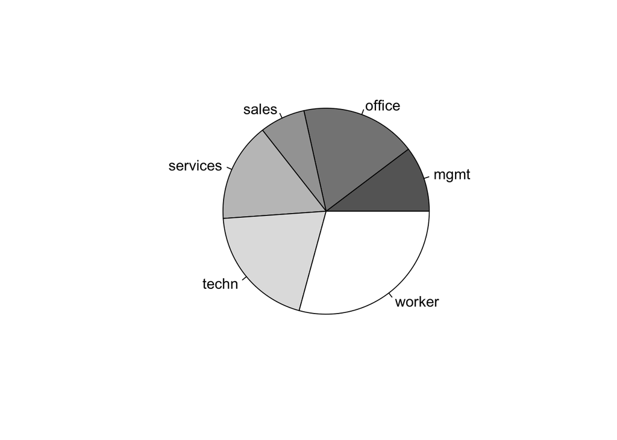

```r
pie(tab, col = gray(seq(0.4, 1.0, length = 6)))
```

```r
#now we explore the factor variables `gender` and `occupation`.
table(CPS1985$gender)
```

```
female   male
   245    289
```

```r
CPS1985$gender <- factor(CPS1985$gender,
                             levels = c("female",'male'))

attach(CPS1985)                 # attach the data set to avoid use of $
table(gender, occupation)       # no name_df$name_var necessary
```

```
        occupation
gender   mgmt office sales services techn worker
  female   21     76    17       49    52     30
  male     34     21    21       34    53    126
```

```r
prop.table(table(gender, occupation))
```

```
        occupation
gender         mgmt     office      sales   services      techn     worker
  female 0.03932584 0.14232210 0.03183521 0.09176030 0.09737828 0.05617978
  male   0.06367041 0.03932584 0.03932584 0.06367041 0.09925094 0.23595506
```

```r
prop.table(table(gender, occupation), 2) #what is the difference ?
```

```
        occupation
gender        mgmt    office     sales  services     techn    worker
  female 0.3818182 0.7835052 0.4473684 0.5903614 0.4952381 0.1923077
  male   0.6181818 0.2164948 0.5526316 0.4096386 0.5047619 0.8076923
```

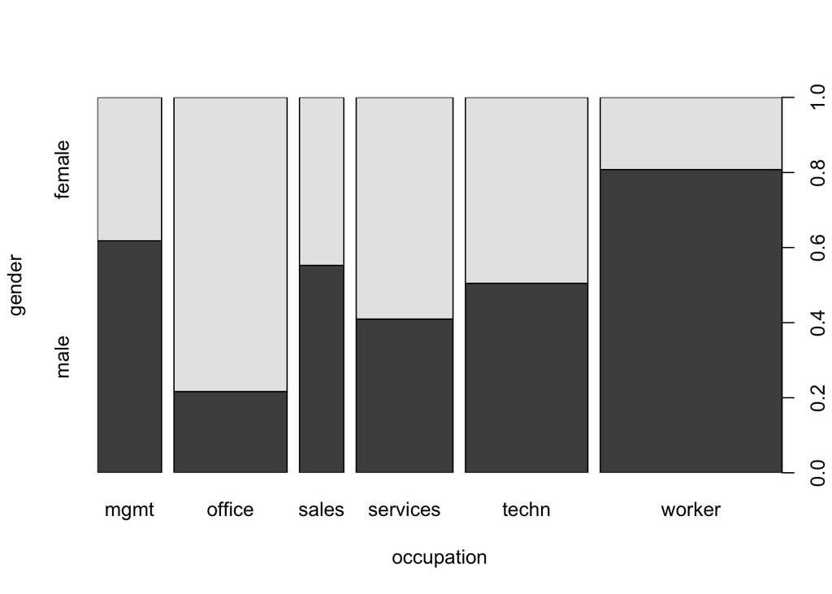

```r
plot(gender ~ occupation, data = CPS1985)
```

```r
detach(CPS1985)                 # now detach when work is done


#lets explore a factor and a numeric variable
attach(CPS1985)
#help(tapply)
tapply(wage, gender, mean)
```

```
  female     male
7.878857 9.994913
```

```r
tapply(wage, gender, median)
```

```
female   male
  6.80   8.93
```

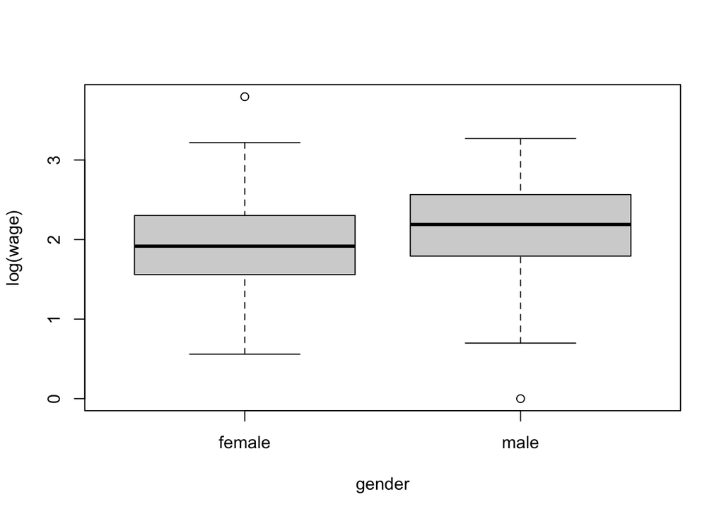

```r
boxplot(log(wage) ~ gender, data = CPS1985)
```

```r
tapply((wage), list(gender, occupation), mean)
```

```
           mgmt   office    sales services    techn   worker
female 11.05619 7.404211 5.241765 6.059388 11.10500 5.731333
male   13.72176 7.489048 9.495714 7.226471 12.77396 9.068175
```

```r
tapply((wage), list(gender, occupation), median)
```

```
        mgmt office sales services techn worker
female 10.00   7.00  4.55     5.00    10  4.975
male   13.99   7.69  9.42     5.89    12  8.500
```

# A bit more general programming concepts

Here we will learn about relational operators.

As already mentioned remember not not to mix up `==` and `=`, where the latter is used for assignment and the former checks equality.

```r
3 == (2 + 1)
"intermediate" != "r"
(1 + 2) > 4
dimi <- c(1, 22, 4, 5, 7)
dimi > 5
```

Logical operators can be combined,for example

```r
TRUE & TRUE #logical AND
FALSE | TRUE #logicak OR
5 <= 5 & 2 < 3
3 < 4 | 7 < 6
```

### Conditionals statements or expressions

In programming, conditionals (equally called conditional statements, conditional expressions and conditional constructs) are programming language constructs that perform different computations or actions or return different values depending on the value of a Boolean expression, called a condition.

Let us focus on the well-known `if` statement in R.

```r
num_attendees <- 30
if (num_attendees > 5) {
  print("You're popular!")
}
```

```
[1] "You're popular!"
```

and if the condition is not full-filled we have the `if else` statement

```r
num_attendees <- 5
if (num_attendees > 5) {
  print("You're popular!")
}else{
  print("You are not so popular!")
}
```

```
[1] "You are not so popular!"
```

### Loops

Loops or Iteration Statements in Programming are helpful when we need a specific task in repetition. They’re essential as they reduce hours of work to seconds. The most famous loops are the `while` and the `for` loops that have different properties and uses.

Because of limited time we will showcase only the `for` loop in R.

```r
ourNames <- c('Dimi', 'Gon', 'Eirik','Anna','Nina','Kjell-Morten','Charis')

# loop version 1
for (p in ourNames) {
  print(p)
}
# loop version 2
for (i in 1:length(ourNames)) {
  print(ourNames[i])
}

#how to iterate over a matrix ?
my_matrix <- matrix(1:12, nrow=3,ncol=4, byrow = TRUE)
for (i in 1:nrow(my_matrix)) {
  for(j in 1:ncol(my_matrix)){
    print(my_matrix[i,j])
  }
}
```

### Write your own function

Creating a function in R is basically the assignment of a function object to a variable.

```r
my_weird_sqrt <- function(x) {
  sqrt(x)+1
}

# use the function
my_weird_sqrt(16)
```

```
[1] 5
```

Irrespective of how long and complicated our R analyses are,it is highly advisable to create functions for tasks that can be nicely generalised. This helps us to write “cleaner” programs, that are easier to read and understand. Of course this requires some expertise on programming, but it is something you can learn and practice from now.

Ideally, in real life applications we can write whole blocks of codes as functions that can be stored in separate R files. This way our codes become modular and we can re-use scripts for more general functions.

For now just remember that if you have an external file defining a function or even a script with more than one functions,we can incorporate all the functions they define into another script with the command:

**source(path/tofile/myFunction.R)**